# Проект "Культурист-датасиентист"

## Дано

Данные сети фитнес центров в виде множества анкет пользователей

## Задача

Провести анализ и подготовить план действий по удержанию клиентов:

- научиться прогнозировать вероятность оттока (на уровне следующего месяца) для каждого клиента;
- сформировать типичные портреты пользователей: выделить несколько наиболее ярких групп и охарактеризовать их основные свойства;
- проанализировать основные признаки, наиболее сильно влияющие на отток;
- сформулировать основные выводы и разработать рекомендации по повышению качества работы с клиентами:

  1) выделить целевые группы клиентов;

  2) предложить меры по снижению оттока;

  3) определить другие особенности взаимодействия с клиентами.

## Описание данных

- `'Churn`' — факт оттока в текущем месяце;

**Текущие поля в датасете:**

**Данные пользователя за предыдущий до проверки факта оттока месяц:**

- `'gender'` — пол
- `'Near_Location'` — проживание или работа в районе, где находится фитнес-центр
- `'Partner'` — сотрудник компании-партнёра клуба (сотрудничество с компаниями, чьи сотрудники могут получать скидки на абонемент — в таком случае фитнес-центр хранит информацию о работодателе клиента)
- `Promo_friends` — факт первоначальной записи в рамках акции «приведи друга» (использовал промо-код от знакомого при оплате первого абонемента)
- `'Phone'` — наличие контактного телефона
- `'Age'` — возраст
- `'Lifetime'` — время с момента первого обращения в фитнес-центр (в месяцах)

**Информация на основе журнала посещений, покупок и информация о текущем статусе абонемента клиента**

- `'Contract_period'` — длительность текущего действующего абонемента (месяц, 3 месяца, 6 месяцев, год)
- `'Month_to_end_contract'` — срок до окончания текущего действующего абонемента (в месяцах)
- `'Group_visits'` — факт посещения групповых занятий
- `'Avg_class_frequency_total'` — средняя частота посещений в неделю за все время с начала действия абонемента
- `'Avg_class_frequency_current_month'` — средняя частота посещений в неделю за предыдущий месяц
- `'Avg_additional_charges_total'` — суммарная выручка от других услуг фитнес-центра: кафе, спорт-товары, косметический и массажный салон

# Содержание проекта:

### Обзор и предобработка данных

### Исследовательский анализ данных

### Построение модели прогнозирования оттока пользователей

### Кластеризация пользователей

### Общий вывод

```python
import pandas as pd
import matplotlib.pyplot as plt
import numpy as np
import seaborn as sns
import math
from sklearn.model_selection import train_test_split
from sklearn.linear_model import LogisticRegression
from sklearn.preprocessing import StandardScaler
from sklearn.ensemble import RandomForestRegressor
from sklearn.ensemble import RandomForestClassifier
from sklearn.metrics import accuracy_score, precision_score, recall_score, f1_score
import warnings
warnings.filterwarnings('ignore')
from scipy.cluster.hierarchy import dendrogram, linkage
from sklearn.cluster import KMeans
```

## Обзор и предобработка данных

```python
df = pd.read_csv('/datasets/gym_churn.csv')
df
```

|  | gender | Near_Location | Partner | Promo_friends | Phone | Contract_period | Group_visits | Age | Avg_additional_charges_total | Month_to_end_contract | Lifetime | Avg_class_frequency_total | Avg_class_frequency_current_month | Churn |
| --- | --- | --- | --- | --- | --- | --- | --- | --- | --- | --- | --- | --- | --- | --- |
| 0 | 1 | 1 | 1 | 1 | 0 | 6 | 1 | 29 | 14.227470 | 5.0 | 3 | 0.020398 | 0.000000 | 0 |
| 1 | 0 | 1 | 0 | 0 | 1 | 12 | 1 | 31 | 113.202938 | 12.0 | 7 | 1.922936 | 1.910244 | 0 |
| 2 | 0 | 1 | 1 | 0 | 1 | 1 | 0 | 28 | 129.448479 | 1.0 | 2 | 1.859098 | 1.736502 | 0 |
| 3 | 0 | 1 | 1 | 1 | 1 | 12 | 1 | 33 | 62.669863 | 12.0 | 2 | 3.205633 | 3.357215 | 0 |
| 4 | 1 | 1 | 1 | 1 | 1 | 1 | 0 | 26 | 198.362265 | 1.0 | 3 | 1.113884 | 1.120078 | 0 |
| ... | ... | ... | ... | ... | ... | ... | ... | ... | ... | ... | ... | ... | ... | ... |
| 3995 | 1 | 1 | 1 | 0 | 1 | 12 | 0 | 33 | 2.406023 | 12.0 | 8 | 2.284497 | 2.349070 | 0 |
| 3996 | 0 | 1 | 0 | 0 | 1 | 1 | 1 | 29 | 68.883764 | 1.0 | 1 | 1.277168 | 0.292859 | 1 |
| 3997 | 1 | 1 | 1 | 1 | 1 | 12 | 0 | 28 | 78.250542 | 11.0 | 2 | 2.786146 | 2.831439 | 0 |
| 3998 | 0 | 1 | 1 | 1 | 1 | 6 | 0 | 32 | 61.912657 | 5.0 | 3 | 1.630108 | 1.596237 | 0 |
| 3999 | 1 | 0 | 1 | 0 | 0 | 12 | 1 | 30 | 178.861814 | 12.0 | 1 | 1.101832 | 1.035270 | 0 |

4000 rows × 14 columns

```python
df.info()
```

```
<class 'pandas.core.frame.DataFrame'>
RangeIndex: 4000 entries, 0 to 3999
Data columns (total 14 columns):
gender                               4000 non-null int64
Near_Location                        4000 non-null int64
Partner                              4000 non-null int64
Promo_friends                        4000 non-null int64
Phone                                4000 non-null int64
Contract_period                      4000 non-null int64
Group_visits                         4000 non-null int64
Age                                  4000 non-null int64
Avg_additional_charges_total         4000 non-null float64
Month_to_end_contract                4000 non-null float64
Lifetime                             4000 non-null int64
Avg_class_frequency_total            4000 non-null float64
Avg_class_frequency_current_month    4000 non-null float64
Churn                                4000 non-null int64
dtypes: float64(4), int64(10)
memory usage: 437.6 KB
```

```python
df.duplicated().value_counts()
```

```
False    4000
dtype: int64
```

```python
df.columns = [x.lower() for x in df.columns]
```

```python
df['month_to_end_contract'] = df['month_to_end_contract'].astype('int')
```

## Вывод

- пропуски отсутсвуют
- дубликаты отсутсвуют
- названия столбцов приведены к нижнему регистру

## Исследовательский анализ данных

```python
df.describe()
```

|  | gender | near_location | partner | promo_friends | phone | contract_period | group_visits | age | avg_additional_charges_total | month_to_end_contract | lifetime | avg_class_frequency_total | avg_class_frequency_current_month | churn |
| --- | --- | --- | --- | --- | --- | --- | --- | --- | --- | --- | --- | --- | --- | --- |
| count | 4000.000000 | 4000.000000 | 4000.000000 | 4000.000000 | 4000.000000 | 4000.000000 | 4000.000000 | 4000.000000 | 4000.000000 | 4000.000000 | 4000.000000 | 4000.000000 | 4000.000000 | 4000.000000 |
| mean | 0.510250 | 0.845250 | 0.486750 | 0.308500 | 0.903500 | 4.681250 | 0.412250 | 29.184250 | 146.943728 | 4.322750 | 3.724750 | 1.879020 | 1.767052 | 0.265250 |
| std | 0.499957 | 0.361711 | 0.499887 | 0.461932 | 0.295313 | 4.549706 | 0.492301 | 3.258367 | 96.355602 | 4.191297 | 3.749267 | 0.972245 | 1.052906 | 0.441521 |
| min | 0.000000 | 0.000000 | 0.000000 | 0.000000 | 0.000000 | 1.000000 | 0.000000 | 18.000000 | 0.148205 | 1.000000 | 0.000000 | 0.000000 | 0.000000 | 0.000000 |
| 25% | 0.000000 | 1.000000 | 0.000000 | 0.000000 | 1.000000 | 1.000000 | 0.000000 | 27.000000 | 68.868830 | 1.000000 | 1.000000 | 1.180875 | 0.963003 | 0.000000 |
| 50% | 1.000000 | 1.000000 | 0.000000 | 0.000000 | 1.000000 | 1.000000 | 0.000000 | 29.000000 | 136.220159 | 1.000000 | 3.000000 | 1.832768 | 1.719574 | 0.000000 |
| 75% | 1.000000 | 1.000000 | 1.000000 | 1.000000 | 1.000000 | 6.000000 | 1.000000 | 31.000000 | 210.949625 | 6.000000 | 5.000000 | 2.536078 | 2.510336 | 1.000000 |
| max | 1.000000 | 1.000000 | 1.000000 | 1.000000 | 1.000000 | 12.000000 | 1.000000 | 41.000000 | 552.590740 | 12.000000 | 31.000000 | 6.023668 | 6.146783 | 1.000000 |

```python
dfChurn = df.groupby('churn',as_index = False).mean()
dfChurn
```

|  | churn | gender | near_location | partner | promo_friends | phone | contract_period | group_visits | age | avg_additional_charges_total | month_to_end_contract | lifetime | avg_class_frequency_total | avg_class_frequency_current_month |
| --- | --- | --- | --- | --- | --- | --- | --- | --- | --- | --- | --- | --- | --- | --- |
| 0 | 0 | 0.510037 | 0.873086 | 0.534195 | 0.353522 | 0.903709 | 5.747193 | 0.464103 | 29.976523 | 158.445715 | 5.283089 | 4.711807 | 2.024876 | 2.027882 |
| 1 | 1 | 0.510839 | 0.768143 | 0.355325 | 0.183789 | 0.902922 | 1.728558 | 0.268615 | 26.989632 | 115.082899 | 1.662582 | 0.990575 | 1.474995 | 1.044546 |

```python
len(df[df['churn'] == 0]), len(df[df['churn'] == 1])
```

```
(2939, 1061)
```

#### Строим распределения бо бинарным признакам

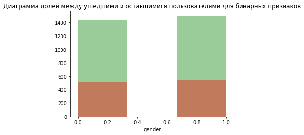

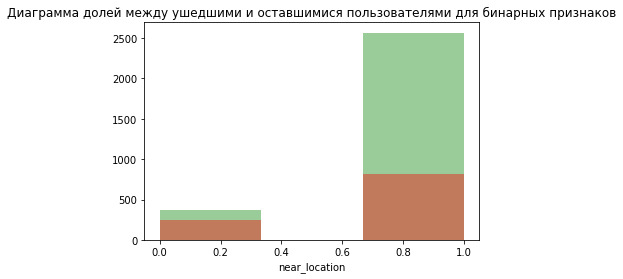

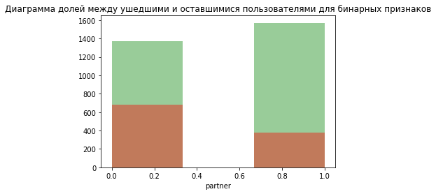

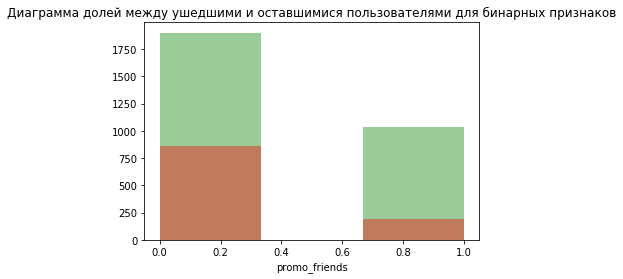

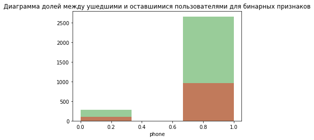

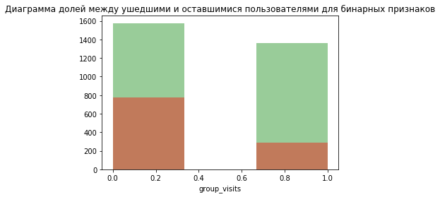

```python
binary = ['gender','near_location','partner','promo_friends','phone','group_visits']
for row in binary:
    plt.title('Диаграмма долей между ушедшими и оставшимися пользователями для бинарных признаков')
    sns.distplot(X0[row],kde = False,color = 'green', bins = 3)
    sns.distplot(X1[row],kde = False,color = 'red', bins = 3)
    plt.show()
```

#### Строим распределения дискретным признакам

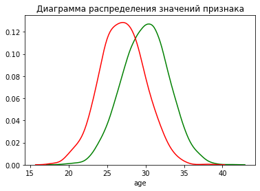

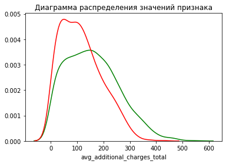

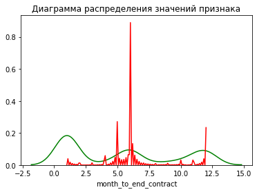

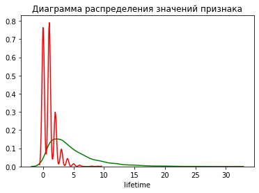

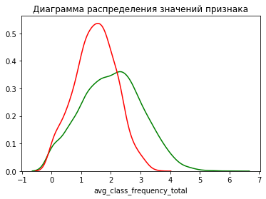

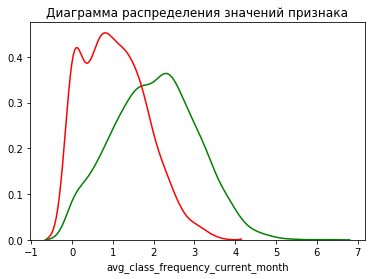

```python
not_binary = ['age','avg_additional_charges_total','month_to_end_contract','lifetime','avg_class_frequency_total','avg_class_frequency_current_month']
for row in not_binary:
    plt.title('Диаграмма распределения значений признака')
    sns.distplot(X0[row],color = 'green',hist = False, bins = 10)
    sns.distplot(X1[row],color = 'red', hist = False, bins = 10)
    plt.show()
```

[figure not shown]

```python
plt.figure(figsize=(14, 12))
plt.title('Тепловая диаграмма распределения значений корреляции между признаками')
plt.xlabel('Название признака')
plt.ylabel('Название признака')
sns.heatmap(df.corr(),annot=True,linewidths=.5)
plt.show()
```

## Вывод

- Отсутсвующих признаков нет

Назовём пользователей оттока - g1, остающихся пользователей - g0

## Построение модели прогнозирования оттока пользователей

#### Так как основной задачей является прогнозирование факта оттока,т.е определение к какой из двух групп будет относится клиент, то мы имеем задачу бинарной классификации.

```python
X = df.drop('churn', axis = 1)#выделяем признаки
y = df['churn']#определяем целевую признак

# разделяем модель на обучающую и валидационную выборку
X_train, X_test, y_train, y_test = train_test_split(X, y, test_size=0.2, random_state=0)

scaler = StandardScaler()
scaler.fit(X_train)

# стандартизируем данные
X_train_st = scaler.transform(X_train)
X_test_st = scaler.transform(X_test)
```

#### В качестве первого способа решения примененяем метод *логистической регрессии*.

```python
model_logic = LogisticRegression()
model_logic.fit(X_train, y_train)
y_pred_logic = model_logic.predict(X_test)
```

#### В качестве второго способа решения примененяем метод "*Случайного леса*".

```python
model_forest = RandomForestClassifier(n_estimators = 100,random_state = 0)
model_forest.fit(X_train, y_train)
y_pred_forest = model_forest.predict(X_test)
```

```python
def metrics(y_true,y_pred, title = "Метрики классификации"):
    print(title)
    print('\tAccuracy: {:.2f}'.format(accuracy_score(y_true, y_pred)))
    print('\tPrecision: {:.2f}'.format(precision_score(y_true, y_pred)))
    print('\tRecall: {:.2f}'.format(recall_score(y_true, y_pred)))
```

```python
metrics(y_test,y_pred_logic)
```

```
Метрики классификации
	Accuracy: 0.93
	Precision: 0.86
	Recall: 0.83
```

```python
metrics(y_test,y_pred_forest)
```

```
Метрики классификации
	Accuracy: 0.92
	Precision: 0.84
	Recall: 0.82
```

## Вывод

Метод *логистической регрессии* иммеет более точный прогноз, так как полученные для данного метода метрики **Accuracy**,**Precision**,**Recall** ближе к единице, чем метрики метода *Случайный лес*

## Кластеризация пользователей

```python
#профодим стандартизацию
sc = StandardScaler()
X_sc = sc.fit_transform(X)
linked = linkage(X_sc, method = 'ward')#строим матрицу расстоянийи
```

[figure not shown]

```python
plt.figure(figsize=(20, 15))
dendrogram(linked, orientation='top')
plt.title('Иерархическая ластеризация')
plt.ylabel('Расстояние между кластерами')
plt.show()
```

## Вывод:

Оптимальное число кластеров **n = 4шт.**, в соответсвии с четырьмя различными цветами на дендограмме агломеративной иерархической кластеризации

Далее применяем алгоритм **K-means**. Возьмём число кластеров **n=5 шт.** в соответсвии с условием проекта

```python
km = KMeans(n_clusters = 5) ### нужен random_state

# прогнозируем кластеры для наблюдений
labels = km.fit_predict(X_sc)
df['clusters'] = labels
```

```python
df.groupby('clusters',as_index = False).mean()
```

|  | clusters | gender | near_location | partner | promo_friends | phone | contract_period | group_visits | age | avg_additional_charges_total | month_to_end_contract | lifetime | avg_class_frequency_total | avg_class_frequency_current_month | churn |
| --- | --- | --- | --- | --- | --- | --- | --- | --- | --- | --- | --- | --- | --- | --- | --- |
| 0 | 0 | 0.495050 | 0.000000 | 0.463366 | 0.079208 | 1.000000 | 2.352475 | 0.215842 | 28.477228 | 135.457501 | 2.198020 | 2.809901 | 1.660461 | 1.477324 | 0.443564 |
| 1 | 1 | 0.560142 | 0.976415 | 0.359670 | 0.238208 | 0.998821 | 2.685142 | 0.469340 | 30.110849 | 161.665710 | 2.476415 | 4.889151 | 2.846441 | 2.844923 | 0.067217 |
| 2 | 2 | 0.484512 | 1.000000 | 0.351072 | 0.237490 | 1.000000 | 1.954726 | 0.341541 | 28.165210 | 131.444212 | 1.862589 | 2.430500 | 1.246208 | 1.011058 | 0.515488 |
| 3 | 3 | 0.503490 | 0.959123 | 0.782652 | 0.573280 | 1.000000 | 10.923230 | 0.546361 | 29.991027 | 160.881742 | 9.983051 | 4.748754 | 1.977676 | 1.970029 | 0.027916 |
| 4 | 4 | 0.522078 | 0.862338 | 0.470130 | 0.306494 | 0.000000 | 4.787013 | 0.425974 | 29.301299 | 143.957664 | 4.475325 | 3.924675 | 1.847220 | 1.716369 | 0.267532 |

## Вывод

В соответсвии со средними значениями признаков сложно оценить оптимальность разбиения на кластеры. Если искать зависимости в цифрах между признаками, то на глаз она не видна.

*p.s. Что здесь можно сразу заметить?*

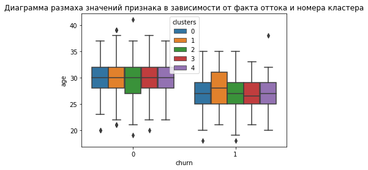

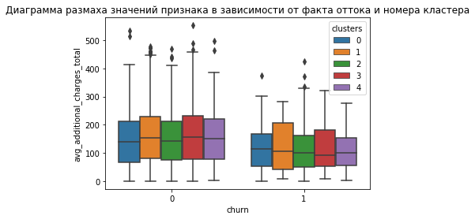

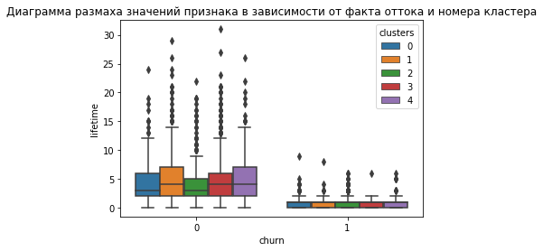

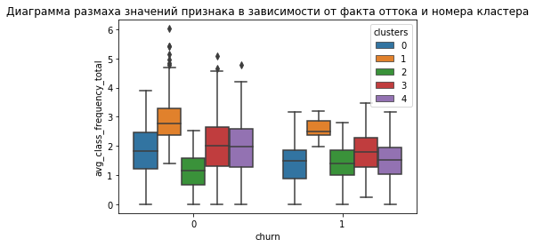

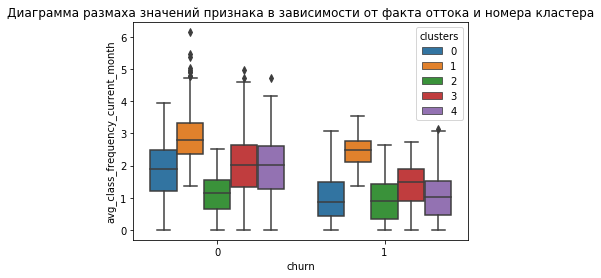

```python
X_names_not_binar = X.drop(['gender','near_location','partner','group_visits','promo_friends',
                           'phone','contract_period','month_to_end_contract'],axis = 1)
for row in X_names_not_binar:
    plt.title('Диаграмма размаха значений признака в зависимости от факта оттока и номера кластера')
    sns.boxplot(x = 'churn', y = row, hue = 'clusters', data = df)
    plt.show()
```

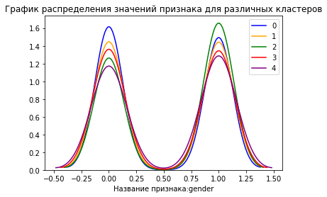

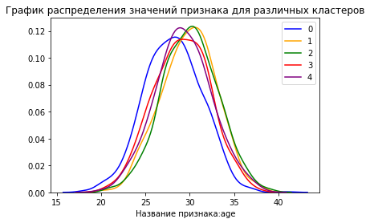

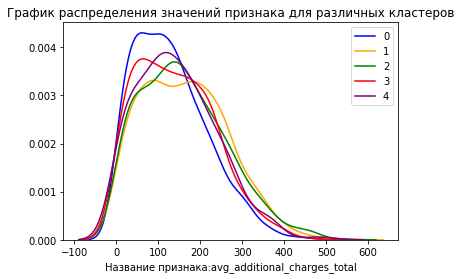

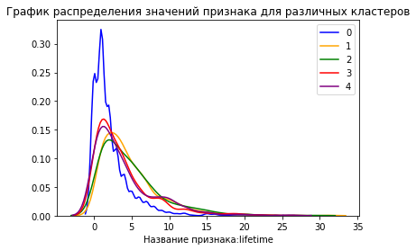

[figure not shown]

[figure not shown]

```python
X_names = X.drop(['contract_period','phone','promo_friends','partner','near_location','month_to_end_contract'
                  ,'group_visits'],axis = 1).columns.to_list()
clusters = [0,1,2,3,4]
colors = ['blue','orange','green','red','purple']
for row in X_names:
    for i in clusters:
        sns.distplot(df[df['clusters']==clusters[i]][row],color = colors[i], hist = False, label = clusters[i])
    plt.title('График распределения значений признака для различных кластеров')
    plt.xlabel('Название признака:{}'.format(row))
    plt.show()
```

```python
df_ratio = df.groupby('clusters',as_index = False).agg({'churn':'sum','gender':'count'})
df_ratio.columns = ['clusters','churn','count']
```

```python
df_ratio['ratio'] = df_ratio['churn']/ df_ratio['count']
print(df_ratio)
```

```
   clusters  churn  count     ratio
0         0    224    505  0.443564
1         1     57    848  0.067217
2         2    649   1259  0.515488
3         3     28   1003  0.027916
4         4    103    385  0.267532
```

## Вывод

- Исходя из графиков распределения можно заметить выделяющиеся кластеры под номерами **0** и **2**. При этом исходя из рассчитаных средних значений для признаков, данные кластеры имеют, в среднем, самые низкие числовые показатели по всем небинарным признакам и самый высокий процент оттока - соответсвенно **44%** и **52%**
- Надёжными к оттоку оказались кластеры под номерами **1** и **3**, которых в среднем характеризует более высокая активность групповых занятий, сравнительно более высокие затраты на другие услуги фитнес центра, более частое посещение

# Общий вывод

### Наиболее яркие группы, оценка по признакам в среднем

**Кластер 0 (результат: 44% пользователей с оттоком)**:

- не работают и не проживают рядом с фитнес центром;
- не пользвовались промокодом;
- **22%** клиентов, посещающих групповые занятия
- **47%** половина клиентов с компаний - партнёров фитнес центра
- длительность текущего абонемента ≈ **2,4 месяца**
- относительно **низкий** объём пользования дргуими услугами фитнес центра

**Кластер 1 (результат: 7% пользователей с оттоком)**:

**Кластер 2 (результат: 51% пользователей с оттоком)**:

- **100%** клиентов рядом с фитнес центром
- **24%** пользовались промокодом
- **34%** клиентов, посещающих групповые занятия
- **35%** пользователей клиентов с компаний партнёров
- длительность текущего абонемента ≈ **2 месяца**
- относительно **низкий** объём пользования дргуими услугами фитнес центра
- среднее кол-во посещений **1 раз** в неделю

**Кластер 3 (результат: 3% пользователей с оттоком)**:

- **97%** клиентов рядом с фитнес центром
- **57%** пользовались промокодом
- **55%** клиентов, посещающих групповые занятия
- **78%** пользователей клиентов с компаний партнёров
- длительность текущего абонемента ≈ **10 месяцев**
- относительно **высокий** объём пользования дргуими услугами фитнес центра
- среднее кол-во посещений около **2 раз** в неделю

### Исходя из полученных результатов, следующие рекомендации, чтобы уменьшить отток пользователей:

- заводить как можно больше компаний партнёров
- направить усилия на привлечение клиентов в групповые занятия
- привлекать клиентов к пользванию другими услугами, помимо фитнеса